# Statistical power of piecewise-regression analyses in single-case experiments addressing behaviour problems

Jürgen Wilbert

2022-02-26

# Bascic reference case

The base design is:

n_sims = 10000  
n = n_sims  
start_value = 15  
level = 15 * -0.5  
trend = rnorm(n_sims, 0, 0.2 * 15/30)  
slope = rnorm(n_sims, 0, 0.2 * abs(15 * -0.5)/20)  
phase_design = list(A = 10, B = 20)  
distribution = poisson

## Example single-cases with the base deisgn parameters

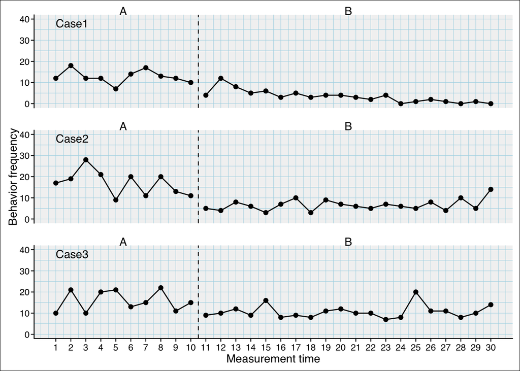

Piecewise-regression model predicting variable ‘values’

| Parameter | B | CI(95%) 2.5% | CI(95%) 97.5% | SE | t | p | Odds Ratio | CI(95%) 2.5% | CI(95%) 97.5% | Yule’s Q | CI(95%) 2.5% | CI(95%) 97.5% |
| --- | --- | --- | --- | --- | --- | --- | --- | --- | --- | --- | --- | --- |
| Intercept | 2.63 | 2.25 | 2.98 | 0.19 | 13.96 | 0.00 | 13.84 | 9.44 | 19.77 | 0.87 | 0.81 | 0.90 |
| Trend mt | -0.02 | -0.08 | 0.04 | 0.03 | -0.51 | 0.61 | 0.98 | 0.93 | 1.05 | -0.01 | -0.04 | 0.02 |
| Level phase B | -0.14 | -0.66 | 0.37 | 0.26 | -0.54 | 0.59 | 0.87 | 0.52 | 1.45 | -0.07 | -0.32 | 0.18 |
| Slope phase B | -0.12 | -0.19 | -0.04 | 0.04 | -2.92 | 0.00 | 0.89 | 0.82 | 0.96 | -0.06 | -0.10 | -0.02 |

Note:  
X²(3) = 115.42; p <.001; AIC = 127

Piecewise-regression model predicting variable ‘values’

| Parameter | B | CI(95%) 2.5% | CI(95%) 97.5% | SE | t | p | Odds Ratio | CI(95%) 2.5% | CI(95%) 97.5% | Yule’s Q | CI(95%) 2.5% | CI(95%) 97.5% |
| --- | --- | --- | --- | --- | --- | --- | --- | --- | --- | --- | --- | --- |
| Intercept | 3.12 | 2.81 | 3.42 | 0.16 | 19.97 | 0.00 | 22.69 | 16.55 | 30.57 | 0.92 | 0.89 | 0.94 |
| Trend mt | -0.06 | -0.11 | 0.00 | 0.03 | -2.07 | 0.04 | 0.95 | 0.90 | 1.00 | -0.03 | -0.05 | 0.00 |
| Level phase B | -0.94 | -1.42 | -0.46 | 0.25 | -3.79 | 0.00 | 0.39 | 0.24 | 0.63 | -0.44 | -0.61 | -0.22 |
| Slope phase B | 0.08 | 0.02 | 0.14 | 0.03 | 2.57 | 0.01 | 1.08 | 1.02 | 1.15 | 0.04 | 0.01 | 0.07 |

Note:  
X²(3) = 72.45; p <.001; AIC = 159

Piecewise-regression model predicting variable ‘values’

| Parameter | B | CI(95%) 2.5% | CI(95%) 97.5% | SE | t | p | Odds Ratio | CI(95%) 2.5% | CI(95%) 97.5% | Yule’s Q | CI(95%) 2.5% | CI(95%) 97.5% |
| --- | --- | --- | --- | --- | --- | --- | --- | --- | --- | --- | --- | --- |
| Intercept | 2.73 | 2.39 | 3.06 | 0.17 | 15.83 | 0.00 | 15.40 | 10.86 | 21.39 | 0.88 | 0.83 | 0.91 |
| Trend mt | 0.00 | -0.05 | 0.06 | 0.03 | 0.17 | 0.87 | 1.00 | 0.95 | 1.06 | 0.00 | -0.02 | 0.03 |
| Level phase B | -0.49 | -0.89 | -0.08 | 0.21 | -2.36 | 0.02 | 0.61 | 0.41 | 0.92 | -0.24 | -0.42 | -0.04 |
| Slope phase B | 0.00 | -0.06 | 0.06 | 0.03 | 0.07 | 0.94 | 1.00 | 0.94 | 1.06 | 0.00 | -0.03 | 0.03 |

Note:  
X²(3) = 14.12; p <.01; AIC = 166

# Length if A and B phase and intervention effectiveness

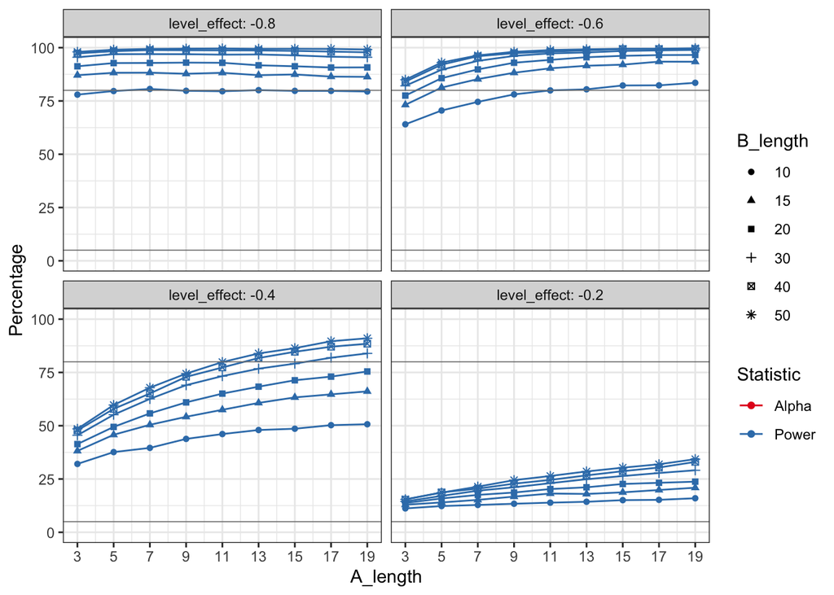

**Iterations:**  
A_length = c(3, 5, 7, 9, 11, 13, 15, 17, 19)  
B_length = c(10, 15, 20, 30, 40, 50)  
level_effect = c(-0.2, -0.4, -0.6, -0.8)  
n_sims = 10000  
**Design:**  
n = n_sims  
start_value = 15  
level = 15 * level_effect  
trend = rnorm(n_sims, 0, 0.2 * 15/(A_length + B_length))  
slope = rnorm(n_sims, 0, 0.25 * abs((15 * level_effect))/B_length)  
phase_design = list(A = A_length, B = B_length)  
distribution = poisson

# Problemintensity, intervention effectiveness, and measurements

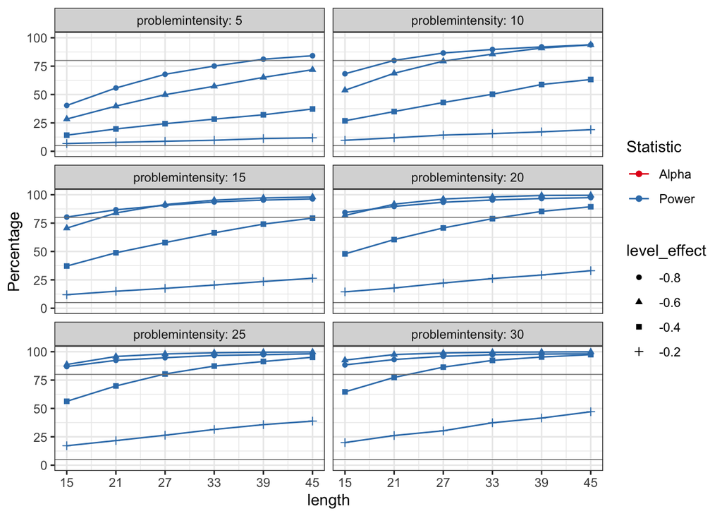

**Iterations:**  
problemintensity = c(5, 10, 15, 20, 25, 30)  
length = c(15, 21, 27, 33, 39, 45)  
level_effect = c(-0.2, -0.4, -0.6, -0.8)  
n_sims = 10000  
**Design:**  
n = n_sims  
start_value = problemintensity  
level = problemintensity * level_effect  
trend = rnorm(n_sims, 0, 0.2 * problemintensity/length)  
slope = rnorm(n_sims, 0, 0.25 * abs(problemintensity * level_effect)/(length * 2/3))  
phase_design = list(A = length/3, B = length * 2/3)  
distribution = poisson

# Strength of trend effect, problemintensity, and measurements

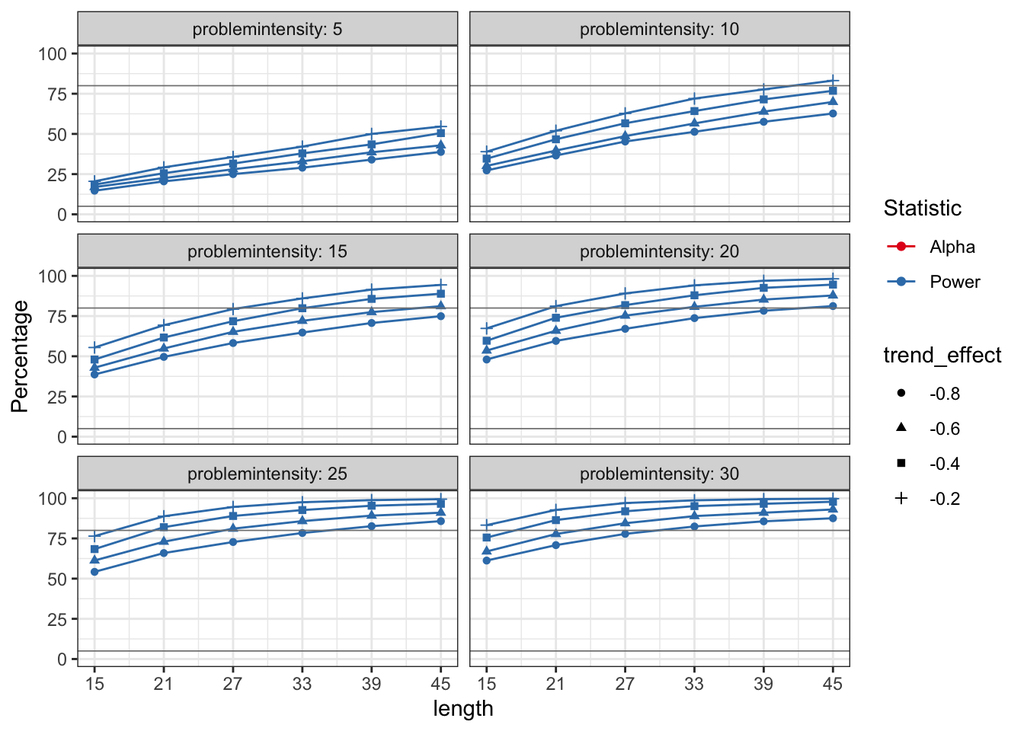

**Iterations:**  
problemintensity = c(5, 10, 15, 20, 25, 30)  
length = c(15, 21, 27, 33, 39, 45)  
trend_effect = c(-0.2, -0.4, -0.6, -0.8)  
n_sims = 10000  
**Design:**  
n = n_sims  
start_value = problemintensity  
level = problemintensity * -0.5  
trend = rnorm(n_sims, 0, abs(trend_effect * problemintensity/length))  
slope = rnorm(n_sims, 0, abs(0.25 * problemintensity * -0.5/(length * 2/3)))  
phase_design = list(A = length * 1/3, B = length * 2/3)  
distribution = poisson